# Error de medición con mediciones repetidas: la brecha del producto

```r
library(lme4)       # modelos de efectos aleatorios
library(lavaan)     # SEM
library(semTools)   # confiabilidad con SEM
knitr::opts_chunk$set(message = FALSE, warning = FALSE)
```

# 1. La idea

La **brecha del producto** es la diferencia entre el PIB observado y el PIB potencial, como porcentaje del potencial. Es una de las variables más usadas en macroeconomía (por ejemplo, en la regla de Taylor), pero **nadie la observa**: el PIB potencial no se mide, se estima. Por eso distintas instituciones publican estimaciones distintas de la brecha para el mismo país y el mismo año.

Si tratamos cada estimación como una medición de la misma brecha verdadera, el modelo es:

$$y_{ij} = \mu + u_i + e_{ij}$$

- $y_{ij}$: estimación de la institución $j$ para el país-año $i$.
- $\mu$: promedio general (cercano a 0, porque la brecha oscila alrededor de cero).
- $u_i$: brecha **verdadera** del país-año $i$, como desviación de $\mu$. Su varianza es $\sigma^2_u$.
- $e_{ij}$: **error aleatorio** de la estimación de la institución $j$. Su varianza es $\sigma^2_e$.

Como $u$ y $e$ son independientes, la varianza total se descompone en dos partes:

$$\text{Var}(y) = \sigma^2_u +
\sigma^2_e$$

La **confiabilidad** de una estimación es la proporción de la varianza total que es varianza verdadera:

$$\rho = \frac{\sigma^2_u}{\sigma^2_u +
\sigma^2_e}$$

Este cociente es el **coeficiente de correlación intraclase (ICC)**.

**Una simplificación:** en la realidad, las instituciones también difieren por razones sistemáticas, porque usan métodos distintos (filtros estadísticos, función de producción). Aquí suponemos que todas miden la misma brecha con el mismo nivel de error aleatorio, y que ninguna sobreestima o subestima en promedio.

# 2. Los datos

Tenemos 30 países observados durante 10 años (300 país-años). Para cada país-año hay cuatro estimaciones de la brecha del producto.

| Variable | Descripción |
| --- | --- |
| `pais`, `anio` | Identificadores |
| `fmi`, `ocde`, `ce`, `bc` | Brecha estimada por el FMI, la OCDE, la Comisión Europea y el banco central (% del PIB potencial) |
| `verdadera` | Brecha **verdadera** (% del PIB potencial) |
| `inflacion` | Inflación anual (%) |
| `tasa` | Tasa de interés de política monetaria (%) |

Los datos son simulados. Por eso conocemos `verdadera`; con datos reales nunca se observa. Aquí la usamos para verificar que los métodos funcionan.

```r
d <- read.csv("brecha_producto.csv")
d$id <- paste(d$pais, d$anio)          # identificador del país-año
fuentes <- c("fmi", "ocde", "ce", "bc")
head(d)
```

```
##   pais anio verdadera   fmi  ocde    ce    bc inflacion  tasa       id
## 1  P01 2011     -1.87 -4.84 -0.56 -2.24 -2.26      5.60  8.16 P01 2011
## 2  P01 2012     -1.39 -4.78 -1.54 -0.21 -3.22      2.63  3.51 P01 2012
## 3  P01 2013     -1.10 -1.71 -1.85 -1.03 -0.79      3.60  6.27 P01 2013
## 4  P01 2014      1.53  0.64  1.68  2.90  2.70      1.88  4.97 P01 2014
## 5  P01 2015      3.70  4.67  3.65  3.55  4.20      6.88 13.53 P01 2015
## 6  P01 2016      1.51  2.15  3.59  3.40 -0.38      4.51  7.66 P01 2016
```

Los datos vienen en **formato ancho** (una fila por país-año). Para el modelo de efectos aleatorios necesitamos **formato largo** (una fila por estimación):

```r
largo <- data.frame(id      = rep(d$id, 4),
                    fuente  = rep(fuentes, each = nrow(d)),
                    y       = c(d$fmi, d$ocde, d$ce, d$bc))
head(largo[order(largo$id), ], 8)
```

```
##           id fuente     y
## 1   P01 2011    fmi -4.84
## 301 P01 2011   ocde -0.56
## 601 P01 2011     ce -2.24
## 901 P01 2011     bc -2.26
## 2   P01 2012    fmi -4.78
## 302 P01 2012   ocde -1.54
## 602 P01 2012     ce -0.21
## 902 P01 2012     bc -3.22
```

## 2.1 Variación dentro y entre país-años

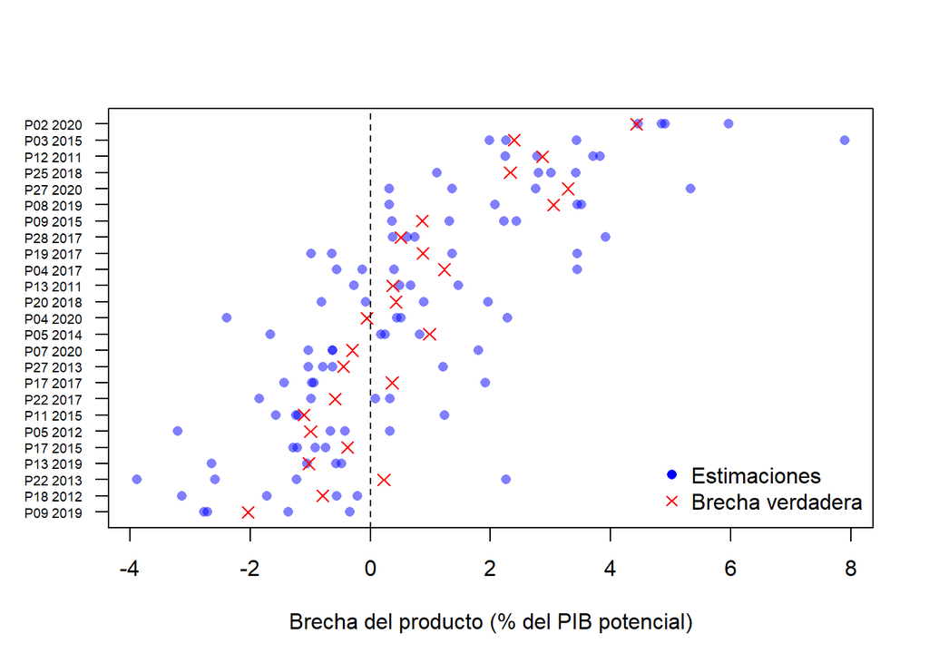

```r
set.seed(1)
muestra <- sample(d$id, 25)
s <- d[d$id %in% muestra, ]
s <- s[order(rowMeans(s[fuentes])), ]

plot(NA, xlim = range(s[fuentes]), ylim = c(1, 25), yaxt = "n",
     xlab = "Brecha del producto (% del PIB potencial)", ylab = "")
for (f in fuentes) points(s[[f]], 1:25, pch = 16, col = rgb(0, 0, 1, .5))
points(s$verdadera, 1:25, pch = 4, col = "red", cex = 1.2)
axis(2, at = 1:25, labels = s$id, las = 1, cex.axis = .6)
abline(v = 0, lty = 2)
legend("bottomright", c("Estimaciones", "Brecha verdadera"), pch = c(16, 4),
       col = c("blue", "red"), bty = "n")
```

Cada fila es un país-año. La dispersión **horizontal dentro de una fila** es el error ($\sigma^2_e$): las instituciones no se ponen de acuerdo. Las diferencias **entre filas** son la variación entre país-años, que mezcla diferencias verdaderas ($\sigma^2_u$) y error.

**Pregunta:** ¿hay país-años en los que las instituciones ni siquiera coinciden en el signo de la brecha? ¿Qué implica eso para un banco central?

# 3. Modelo de efectos aleatorios

El modelo de la sección 1 es un **modelo de efectos aleatorios**: $u_i$ es un efecto aleatorio del país-año. En `lme4`:

- `y ~ 1`: solo un intercepto fijo ($\mu$).
- `(1 | id)`: un intercepto aleatorio por país-año ($u_i$).

```r
m_re <- lmer(y ~ 1 + (1 | id), data = largo)
summary(m_re)
```

```
## Linear mixed model fit by REML ['lmerMod']
## Formula: y ~ 1 + (1 | id)
##    Data: largo
##
## REML criterion at convergence: 5045.8
##
## Scaled residuals:
##      Min       1Q   Median       3Q      Max
## -3.02039 -0.57688  0.00339  0.62067  2.94190
##
## Random effects:
##  Groups   Name        Variance Std.Dev.
##  id       (Intercept) 3.797    1.948
##  Residual             2.377    1.542
## Number of obs: 1200, groups:  id, 300
##
## Fixed effects:
##              Estimate Std. Error t value
## (Intercept) -0.009158   0.120980  -0.076
```

En la salida, **Random effects** muestra las dos varianzas: `id (Intercept)` es $\sigma^2_u$ y `Residual` es $\sigma^2_e$. **Fixed effects** muestra $\mu$.

```r
vc    <- as.data.frame(VarCorr(m_re))
var_u <- vc$vcov[vc$grp == "id"]
var_e <- vc$vcov[vc$grp == "Residual"]

c(var_u = var_u, var_e = var_e, ICC = var_u / (var_u + var_e))
```

```
##     var_u     var_e       ICC
## 3.7966355 2.3768085 0.6149947
```

**Lectura:** el ICC indica qué proporción de la variación de **una** estimación de la brecha refleja diferencias verdaderas en el ciclo económico. El resto es ruido.

# 4. Test-retest: la correlación entre dos instituciones

Si solo tuviéramos dos estimaciones, la forma más simple de estimar la confiabilidad es su correlación. Como ambas miden la misma brecha con el mismo error, su correlación estima el ICC:

```r
r <- cor(d[fuentes])
round(r, 3)
```

```
##        fmi  ocde    ce    bc
## fmi  1.000 0.588 0.602 0.631
## ocde 0.588 1.000 0.641 0.601
## ce   0.602 0.641 1.000 0.623
## bc   0.631 0.601 0.623 1.000
```

```r
c(promedio_correlaciones = mean(r[lower.tri(r)]),
  ICC_modelo             = var_u / (var_u + var_e))
```

```
## promedio_correlaciones             ICC_modelo
##              0.6144469              0.6149947
```

Las seis correlaciones varían por azar, pero en promedio coinciden con el ICC. El modelo de efectos aleatorios usa toda la información a la vez.

# 5. Promediar estimaciones: Spearman-Brown

Si promediamos $k$ estimaciones, la varianza verdadera se mantiene, pero la varianza del error se divide entre $k$ (los errores aleatorios se cancelan parcialmente). La confiabilidad del promedio es:

$$\rho_k = \frac{\sigma^2_u}{\sigma^2_u +
\sigma^2_e / k}$$

Esta es la fórmula de **Spearman-Brown**. Es la justificación estadística de usar un “consenso” de varias instituciones.

```r
rel_k <- function(k) var_u / (var_u + var_e / k)
c(una_estimacion = rel_k(1), promedio_4 = rel_k(4))
```

```
## una_estimacion     promedio_4
##      0.6149947      0.8646723
```

Como conocemos la brecha verdadera, podemos verificarlo: la confiabilidad es la correlación al cuadrado entre la estimación y el valor verdadero.

```r
d$promedio <- rowMeans(d[fuentes])

c(fmi_con_verdadera      = cor(d$fmi, d$verdadera)^2,
  promedio_con_verdadera = cor(d$promedio, d$verdadera)^2)
```

```
##      fmi_con_verdadera promedio_con_verdadera
##              0.6345861              0.8856807
```

¿Cuántas estimaciones harían falta para alcanzar cierta confiabilidad?

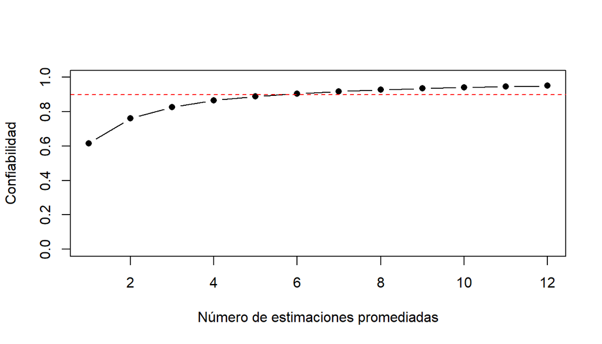

```r
k_vals <- 1:12
plot(k_vals, rel_k(k_vals), type = "b", pch = 16, ylim = c(0, 1),
     xlab = "Número de estimaciones promediadas", ylab = "Confiabilidad")
abline(h = .9, lty = 2, col = "red")
```

Cada estimación adicional aporta menos que la anterior.

# 6. El mismo modelo en SEM

El modelo de efectos aleatorios es un caso particular de un modelo de un factor. En formato ancho:

- El factor `B` es la brecha verdadera ($u_i$). Su varianza es $\sigma^2_u$.
- Las cuatro estimaciones son sus indicadores, con **cargas fijadas en 1**: cada estimación es la brecha verdadera más error.
- Las **varianzas de error son iguales** (etiqueta `e`): las instituciones son igual de precisas.
- Los **interceptos son iguales** (etiqueta `m`): ninguna institución sobreestima o subestima en promedio. Es el $\mu$ del modelo.

En la teoría de medición, indicadores con cargas iguales y errores iguales se llaman **paralelos**.

```r
mod_par <- '
  B =~ 1*fmi + 1*ocde + 1*ce + 1*bc     # brecha verdadera

  fmi  ~~ e*fmi                         # error aleatorio, igual en las 4 fuentes
  ocde ~~ e*ocde
  ce   ~~ e*ce
  bc   ~~ e*bc

  fmi  ~ m*1                            # promedio general (mu)
  ocde ~ m*1
  ce   ~ m*1
  bc   ~ m*1
'
fit_par <- sem(mod_par, data = d)
summary(fit_par)
```

```
## lavaan 0.6-19 ended normally after 17 iterations
##
##   Estimator                                         ML
##   Optimization method                           NLMINB
##   Number of model parameters                         9
##   Number of equality constraints                     6
##
##   Number of observations                           300
##
## Model Test User Model:
##
##   Test statistic                                 5.181
##   Degrees of freedom                                11
##   P-value (Chi-square)                           0.922
##
## Parameter Estimates:
##
##   Standard errors                             Standard
##   Information                                 Expected
##   Information saturated (h1) model          Structured
##
## Latent Variables:
##                    Estimate  Std.Err  z-value  P(>|z|)
##   B =~
##     fmi               1.000
##     ocde              1.000
##     ce                1.000
##     bc                1.000
##
## Intercepts:
##                    Estimate  Std.Err  z-value  P(>|z|)
##    .fmi        (m)   -0.009    0.121   -0.076    0.940
##    .ocde       (m)   -0.009    0.121   -0.076    0.940
##    .ce         (m)   -0.009    0.121   -0.076    0.940
##    .bc         (m)   -0.009    0.121   -0.076    0.940
##
## Variances:
##                    Estimate  Std.Err  z-value  P(>|z|)
##    .fmi        (e)    2.377    0.112   21.213    0.000
##    .ocde       (e)    2.377    0.112   21.213    0.000
##    .ce         (e)    2.377    0.112   21.213    0.000
##    .bc         (e)    2.377    0.112   21.213    0.000
##     B                 3.782    0.358   10.552    0.000
```

`lavaan` estima por máxima verosimilitud (ML). Para comparar con exactitud, estimamos el modelo de efectos aleatorios también por ML (`REML = FALSE`):

```r
m_ml  <- lmer(y ~ 1 + (1 | id), data = largo, REML = FALSE)
vc_ml <- as.data.frame(VarCorr(m_ml))
pe    <- parameterEstimates(fit_par)

data.frame(
  parametro     = c("mu", "var_u", "var_e"),
  efectos_aleat = c(fixef(m_ml), vc_ml$vcov[vc_ml$grp == "id"],
                    vc_ml$vcov[vc_ml$grp == "Residual"]),
  SEM           = c(pe$est[pe$label == "m"][1],
                    pe$est[pe$lhs == "B" & pe$op == "~~"],
                    pe$est[pe$label == "e"][1])
)
```

```
##   parametro efectos_aleat          SEM
## 1        mu  -0.009158333 -0.009158335
## 2     var_u   3.781999355  3.781999343
## 3     var_e   2.376808526  2.376808535
```

Son el mismo modelo.

## 7.1 Omega es Spearman-Brown

El omega de este modelo es la confiabilidad de la **suma** (o del promedio) de las cuatro estimaciones. Con cargas iguales a 1 y errores iguales, la fórmula de omega se reduce a Spearman-Brown:

$$\omega = \frac{4^2 \sigma^2_u}{4^2
\sigma^2_u + 4\sigma^2_e} = \frac{\sigma^2_u}{\sigma^2_u + \sigma^2_e /
4}$$

```r
var_u_ml <- vc_ml$vcov[vc_ml$grp == "id"]
var_e_ml <- vc_ml$vcov[vc_ml$grp == "Residual"]

c(omega          = compRelSEM(fit_par, obs.var = FALSE),
  spearman_brown = var_u_ml / (var_u_ml + var_e_ml / 4))
```

```
##        omega.B spearman_brown
##      0.8642197      0.8642197
```

`obs.var = FALSE` hace que omega use la varianza que predice el modelo, como Spearman-Brown.

## 7.2 ¿Se sostiene el supuesto de error aleatorio?

Si las cuatro estimaciones son paralelas, el modelo restringido debe ajustar bien. Lo comparamos con un modelo **congenérico**, donde cada institución tiene su propia carga, error e intercepto:

```r
fit_cong <- cfa('B =~ fmi + ocde + ce + bc', data = d, meanstructure = TRUE)
fitMeasures(fit_par, c("chisq", "df", "pvalue", "cfi", "rmsea"))
```

```
##  chisq     df pvalue    cfi  rmsea
##  5.181 11.000  0.922  1.000  0.000
```

```r
lavTestLRT(fit_par, fit_cong)
```

```
##
## Chi-Squared Difference Test
##
##          Df    AIC    BIC  Chisq Chisq diff RMSEA Df diff Pr(>Chisq)
## fit_cong  2 5065.0 5109.4 2.7829
## fit_par  11 5049.4 5060.5 5.1813     2.3983     0       9     0.9835
```

Un p-valor alto indica que las restricciones (cargas, errores e interceptos iguales) son compatibles con los datos: las cuatro instituciones pueden tratarse como mediciones equivalentes con error puramente aleatorio.

# 8. Estimar la brecha de cada país-año

Tenemos tres formas de estimar la brecha de un país-año:

1. **Una institución** (por ejemplo, el FMI).
2. **El promedio** de las cuatro instituciones (el “consenso”).
3. **La predicción del modelo** (BLUP): $\hat{\mu} + \hat{u}_i$.

El BLUP no es el promedio simple. Es el promedio “encogido” hacia la media general, en proporción a su confiabilidad:

$$\hat{\mu} + \hat{u}_i = \hat{\mu} +
\rho_k\,(\bar{y}_i - \hat{\mu})$$

Si el consenso indica una brecha muy grande, parte de esa magnitud probablemente es error, y el modelo la corrige hacia cero.

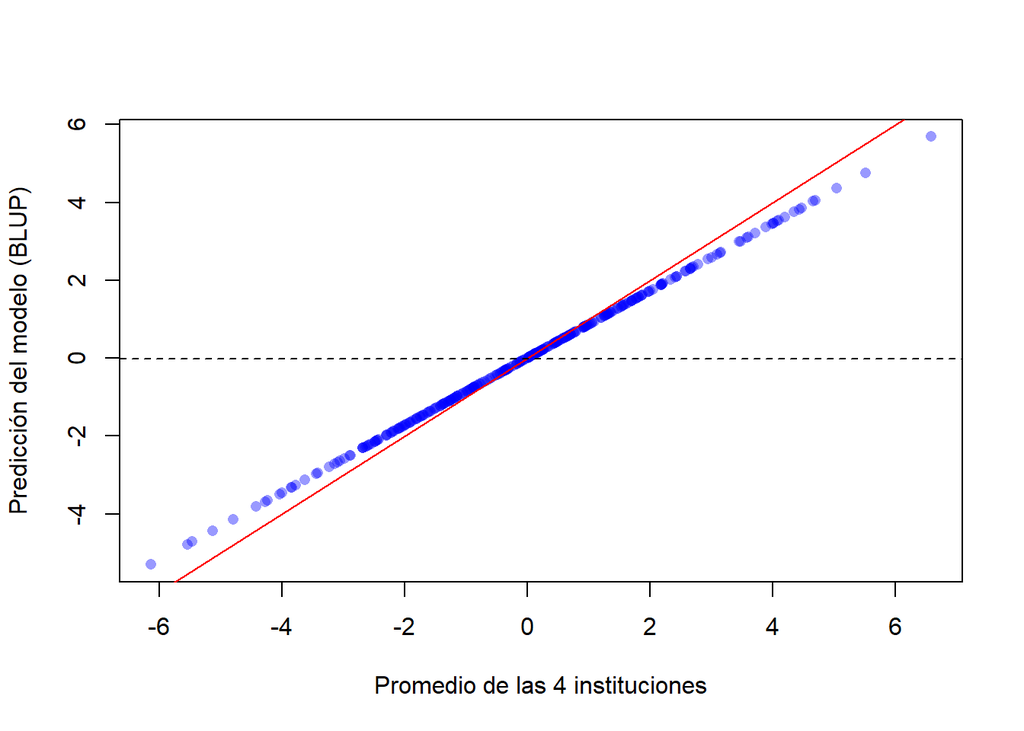

```r
d$blup <- fixef(m_ml) + ranef(m_ml)$id[d$id, 1]

# El puntaje factorial de SEM es lo mismo (más la media)
d$fs <- as.numeric(lavPredict(fit_par)) + pe$est[pe$label == "m"][1]

plot(d$promedio, d$blup, pch = 16, col = rgb(0, 0, 1, .4),
     xlab = "Promedio de las 4 instituciones", ylab = "Predicción del modelo (BLUP)")
abline(0, 1, col = "red")
abline(h = fixef(m_ml), lty = 2)
```

```r
max(abs(d$blup - d$fs))      # BLUP y puntaje factorial coinciden
```

```
## [1] 5.357992e-09
```

Los puntos quedan más cerca de la media general (línea punteada) que la diagonal: eso es el encogimiento.

¿Cuál se acerca más a la brecha verdadera? Lo medimos con la raíz del error cuadrático medio (RMSE), en puntos porcentuales del PIB potencial:

```r
rmse <- function(x) sqrt(mean((x - d$verdadera)^2))
c(una_institucion = rmse(d$fmi), promedio = rmse(d$promedio), blup = rmse(d$blup))
```

```
## una_institucion        promedio            blup
##       1.4732068       0.7099947       0.6468786
```

# 9. ¿Por qué importa? La regla de Taylor

Según la regla de Taylor, el banco central sube la tasa de interés cuando la inflación supera su meta y cuando la economía está por encima de su potencial (brecha positiva):

$$i = r^* + \pi + 0.5\,(\pi - \pi^*) +
0.5\,\text{brecha}$$

En la simulación, la respuesta verdadera a la brecha es 0.5: por cada punto de brecha, la tasa sube medio punto.

Cuando el error está en el **predictor**, su coeficiente se atenúa (se acerca a 0) aproximadamente en proporción a la confiabilidad:

$$\hat{\beta}_{\text{observado}} \approx
\rho \times \beta_{\text{verdadero}}$$

```r
b <- function(x) coef(lm(d$tasa ~ d$inflacion + x))[3]

sem_taylor <- sem(paste(mod_par, "\n tasa ~ inflacion + B"), data = d)
b_sem      <- subset(parameterEstimates(sem_taylor), op == "~" & rhs == "B")$est

data.frame(
  brecha_usada = c("Verdadera", "Una institución (FMI)", "Promedio de 4", "SEM (factor B)"),
  coeficiente  = round(c(b(d$verdadera), b(d$fmi), b(d$promedio), b_sem), 3),
  esperado     = round(c(0.5, 0.5 * rel_k(1), 0.5 * rel_k(4), 0.5), 3))
```

```
##            brecha_usada coeficiente esperado
## 1             Verdadera       0.512    0.500
## 2 Una institución (FMI)       0.322    0.307
## 3         Promedio de 4       0.446    0.432
## 4        SEM (factor B)       0.516    0.500
```

**Lectura:**

- Con la estimación de una sola institución, el coeficiente se atenúa mucho: parecería que el banco central responde al ciclo económico bastante menos de lo que realmente lo hace.
- Promediar instituciones ayuda, pero no elimina la atenuación.
- El modelo SEM usa el factor $B$ (la brecha sin error) como predictor y recupera la respuesta verdadera.
- A diferencia del error en la variable dependiente, que solo atenúa coeficientes estandarizados, el error en el **predictor** atenúa también el coeficiente no estandarizado.

**Nota:** en la simulación, la inflación es independiente de la brecha, así que el error solo afecta al coeficiente de la brecha. Si estuvieran correlacionadas (como sugiere la curva de Phillips), el error en la brecha también sesgaría el coeficiente de la inflación.

# 10. Resumen

1. Con mediciones repetidas, la varianza se descompone en varianza verdadera ($\sigma^2_u$) y error aleatorio ($\sigma^2_e$).
2. La confiabilidad de una medición es el ICC: $\sigma^2_u / (\sigma^2_u + \sigma^2_e)$.
3. Promediar $k$ estimaciones divide la varianza del error entre $k$ (Spearman-Brown). En SEM, eso es omega.
4. El BLUP y el puntaje factorial encogen el consenso hacia la media según su confiabilidad, y se acercan más al valor verdadero.
5. El error en un predictor atenúa su efecto: con una brecha mal medida, el banco central parece menos reactivo al ciclo. Modelar la brecha como variable latente lo corrige.